# A Case-Control Study of the Effect on HbA1c level by Treatment X

J.G.H. Stathakis

# 1 Introduction

The HbA1c test, or glycated haemoglobin test, measures of the average glucose level over a period of several months, quantified as the concentration of glucose complexed with haemoglobin in red blood cells. This test is used to diagnose diabetes, as well as monitor diabetes status. A change in HbA1c level over time will indicate a change in the level of free glucose in the blood, and potentially a decrease in diabetes related symptoms. This study will address whether a particular treatment affects the HbA1c level in a treatment group when compared with a control group.

# 2 Study Description

# 3 Data Cleaning and Formatting

The categorical variables Sex and Group were recorded as binary values, and were converted to descriptive strings prior to analyssis, as per the supplied data dictionary.

To standardise Weight and Height across participants, these measurements were combined into BMI, calculated as weight in kg divided by the square of the height in meters. BMI was then stratified into the following categories: Low $\leq$ 18.5, 18.5 < Normal < 25, 25 $\leq$ Overweight $\leq$ 29.9, Obese 30+. Participants were also divided into two Age groups, $55 \leq$ Age $\geq$ 56.

# 4 Description of the Dataset

## 4.1 Table 1: descriptive statistics of baseline characteristics stratified by exposure:

Prior to analysis, we observed the baseline characteristics to ensure that the participants were a fair representation of the population, that characteristics were evenly distributed within subpopulations as well as between the treatment and control groups. Table 1. contains summary statistics of the baseline characteristics recorded during the study.

In total, there were 1234 participants, divided into roughly equally sized Control (N = 625) and Treatment (N = 609) groups. The sample population was stratified such that the proportion of the following characteristics was reflected in each of the exposure groups. There was an approximately equal division between Male (N = 604, (48.9%)) and Female (630, (51.1%)). The participant ages ranged from 45 to 62 with a mean value of 53. They were divided into two levels, 0 - 55 (N = 1006, (81.5%)) and 56+ (N=228, (18.5%)). The participant weights ranged from 58 to 118 with a mean value of 88.7 BMI ranged from 22.4 to 36.4 with a mean value of 29.7.

Table 1: A table of descriptive statistics of baseline characteristics of the participants of the study, divided based on exposure

|  | Control (N=625) | Treatment (N=609) | Overall (N=1234) |
| --- | --- | --- | --- |
| Sex |  |  |  |
| Male | 324 (51.8%) | 280 (46.0%) | 604 (48.9%) |
| Female | 301 (48.2%) | 329 (54.0%) | 630 (51.1%) |
| Age |  |  |  |
| Mean (SD) | 53.0 (2.90) | 53.1 (2.78) | 53.0 (2.84) |
| Age Categories |  |  |  |
| 0 - 55 | 508 (81.3%) | 498 (81.8%) | 1006 (81.5%) |
| 56+ | 117 (18.7%) | 111 (18.2%) | 228 (18.5%) |
| Weight (kg) |  |  |  |
| Mean (SD) | 88.0 (14.5) | 89.4 (14.7) | 88.7 (14.6) |
| Height (m) |  |  |  |
| Mean (SD) | 172 (8.49) | 173 (8.59) | 172 (8.54) |
| BMI (kg/m²) |  |  |  |
| Mean (SD) | 29.6 (2.37) | 29.8 (2.45) | 29.7 (2.41) |
| BMI_cat |  |  |  |
| Low | 0 (0%) | 0 (0%) | 0 (0%) |
| Normal | 16 (2.6%) | 15 (2.5%) | 31 (2.5%) |
| Overweight | 312 (49.9%) | 285 (46.8%) | 597 (48.4%) |
| Obese | 297 (47.5%) | 309 (50.7%) | 606 (49.1%) |

## 4.2 Distributions of each variable

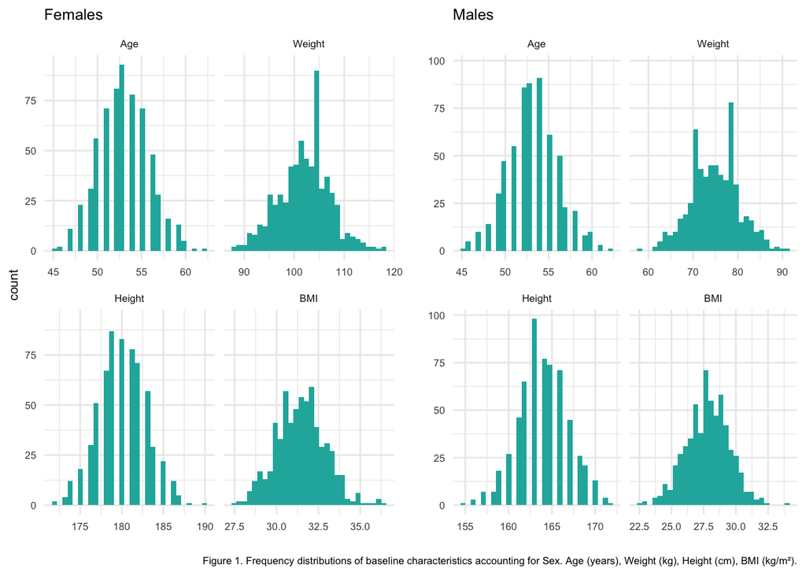

As shown in Figure 1., the characteristic variables of the dataset described in Table 1. are normally distributed when accounting for Sex, although the Weight of both genders has some irregularities that are smoothed out when observing BMI.

[figure not shown]

# 5 Outcome Variable - HbA1c Delta

To observe the effect of the treatment, a difference in HbA1c for each of the control and treatment groups was calculated as ‘Hba1c_delta’. The value prior to treatment was subtracted from the value post-treatment, as we expected a decrease in HbA1c level.

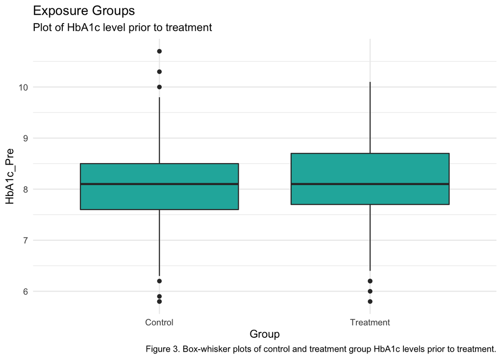

Figure 3. contains a box-whisker plot of HbA1c level prior to treatment between control and exposure groups. As we can see, the measured values are approximately equal between groups, with approximately equal variance, discounting outliers.

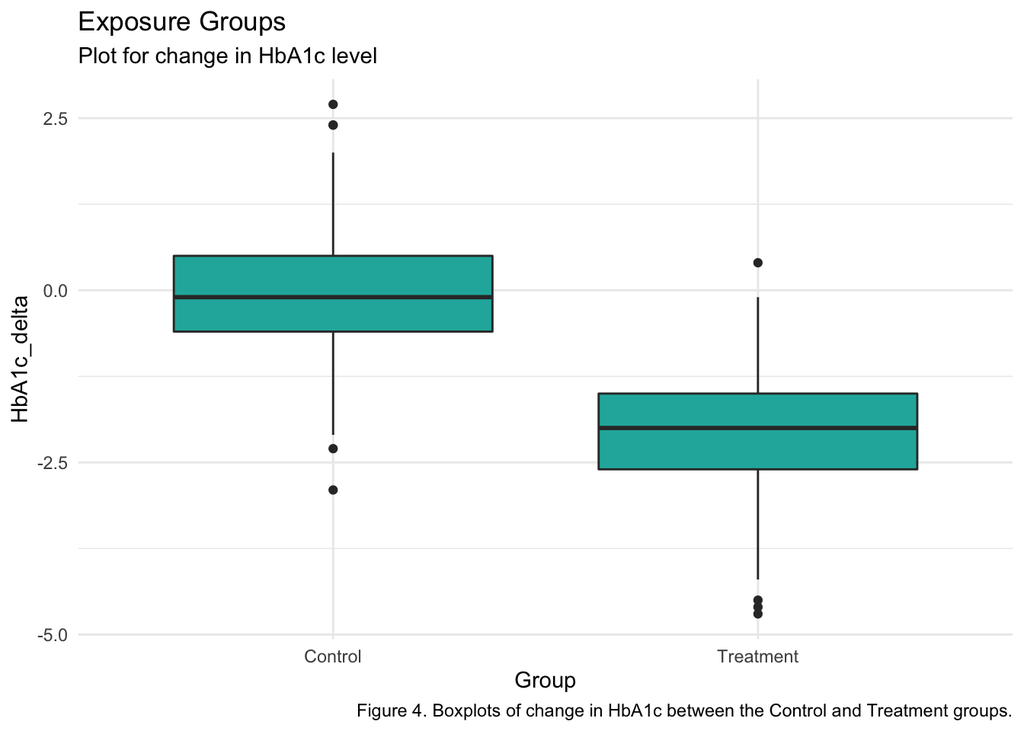

# 6 Outcome Variable Across Subpopulations

Table 2. contains the HbA1c statistics for each subpopulation within the sample.

**Table 2:** average HbA1c levels before and after treatment for control and treatment groups for each subpopulation

| subpop | **Control** **Mean Pre** | **Control** **SD Pre** | **Control** **Mean Post** | **Control** **SD Post** | **Control** **Mean Delta** | **Control** **SD Delta** | **Treatment** **Mean Pre** | **Treatment** **SD Pre** | **Treatment** **Mean Post** | **Treatment** **Mean Post** | **Treatment** **Mean Delta** | **Treatment** **SD Delta** |
| --- | --- | --- | --- | --- | --- | --- | --- | --- | --- | --- | --- | --- |
| **Sex** |  |  |  |  |  |  |  |  |  |  |  |  |
| Sex_Female | 8.10 | 0.742 | 8.06 | 1.107 | −0.03 | 0.811 | 8.21 | 0.685 | 6.16 | 1.061 | −2.05 | 0.844 |
| Sex_Male | 8.03 | 0.706 | 8.00 | 1.079 | −0.04 | 0.789 | 8.08 | 0.738 | 6.00 | 1.123 | −2.07 | 0.792 |
| **BMI** |  |  |  |  |  |  |  |  |  |  |  |  |
| BMI_normal | 8.32 | 0.550 | 7.97 | 1.025 | −0.34 | 0.677 | 8.28 | 0.607 | 6.39 | 0.868 | −1.89 | 0.802 |
| BMI_overweight | 8.01 | 0.724 | 7.98 | 1.083 | −0.03 | 0.771 | 8.07 | 0.763 | 5.99 | 1.154 | −2.08 | 0.823 |
| BMI_obese | 8.11 | 0.727 | 8.08 | 1.106 | −0.03 | 0.832 | 8.21 | 0.660 | 6.17 | 1.035 | −2.04 | 0.820 |
| **Age** |  |  |  |  |  |  |  |  |  |  |  |  |
| Age_55 | 8.04 | 0.727 | 8.00 | 1.109 | −0.04 | 0.813 | 8.13 | 0.715 | 6.07 | 1.084 | −2.06 | 0.804 |
| Age_56 | 8.16 | 0.704 | 8.14 | 1.015 | −0.02 | 0.738 | 8.21 | 0.696 | 6.17 | 1.128 | −2.04 | 0.894 |

To explore the high level of variation of HbA1c delta, we plotted HbA1c delta in Figure 5. as grouped box-whisker plots against Age, Gender and BMI

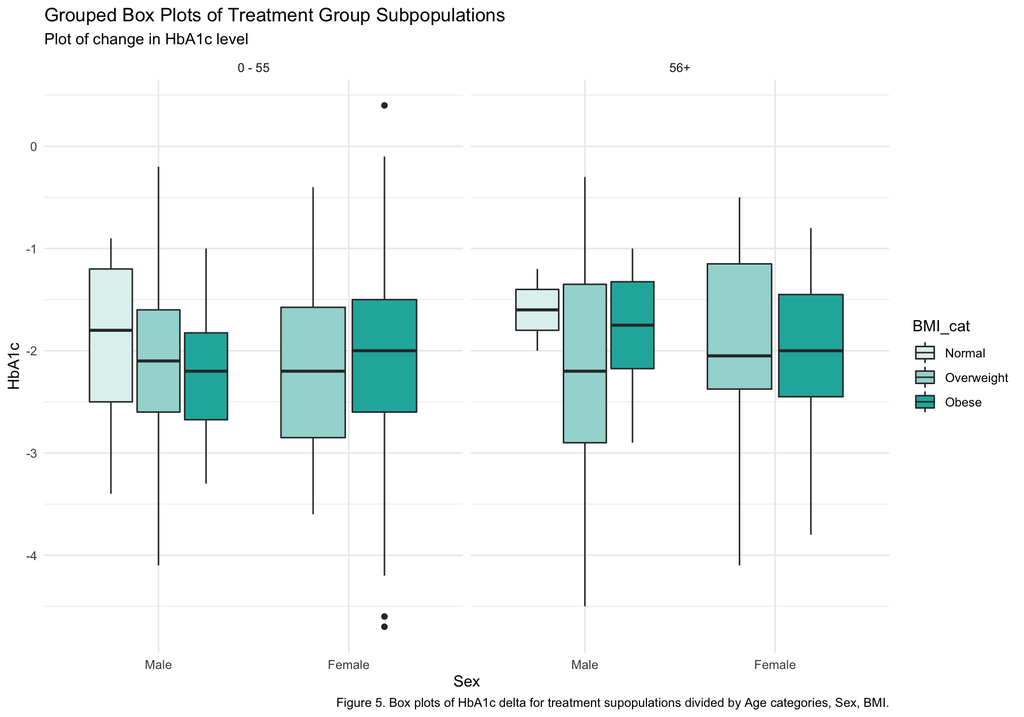

# 7 Conclusion

Without performing any modeling or testing, as per the assessment description, we will conclude with a visual observation. Judging by the plot above, the mean difference in HbA1c_delta between the control and treatment group, we can conclude that for this sample population, the treatment had the effect of decreasing the HbA1c levels in exposed participants by -2.03 (0.826) . Whatsmore, it doesn’t appear as though any of the subpopulations defined by baseline characteristics are more sensitive to the treatment, affecting all roughly equally. The treatment can be considered a success, however further investigation is needed into its effects on specific subpopulations defined by physical characteristics.